# MADS-DAV · Lesson 7 · Networks

## Louvain on the words: five topics

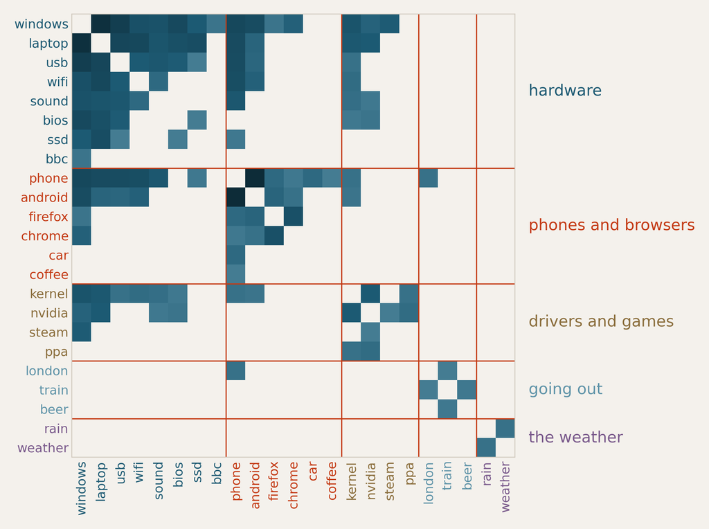

The network: the words of question two. The colours on slide 11 were louvain’s groups.

Five groups, Q = 0.20. Louvain chose the number itself; the eigenvector only cuts in two.

The check: read them. Hardware, phones and browsers, drivers and games, going out, the weather.

Not perfect: coffee and car sit with the phones, bbc with the hardware, each on a single line. Hardware and phones overlap; the border between them is a choice.

5 / can an algorithm find the groups?

MADS-DAV · 35

● 05 — can an algorithm find the groups?

Yes, best as confirmation of what you saw by eye.

Look first: clumps in the drawing, blocks in a matrix sorted by the groups.

The Fiedler vector cuts in two. Louvain finds as many groups as raise modularity.

The karate club is the good case: eye, algorithm and what happened next all agree.

36

Said again. Groups in a network can be seen, as clumps and as blocks, and they can be found, by an eigenvector for two groups or by louvain for more. When you can see them already, the algorithm is not superfluous: it confirms, it makes the boundary exact, and it tells you who sits on it, like member 8. The karate club is convincing because three things agree that were obtained separately: the picture, the algorithm and the split that actually happened. Most networks do not come with that third thing, and then you need the checks of question six.

▲ question 06

are the groups real?

## A method that always finds groups is no evidence that there are any.

1 · Nothing

Run the same method on the network rewired at random, every degree kept. That is the null model.

2 · Triangles

Friends of friends make clumps that beat that null without any groups behind them.

3 · Another period

Real groups come back when the same rule runs on another half of the year.

37

Question six, the one to take into your project. Last lesson k-means found three clusters because it was asked for three, and it found them in shuffled data too. Community detection has the same problem in network form: louvain colours every network into communities, and the pictures always look convincing. So we need checks, and there are three. First, nothing: what does the method find in a network that has no groups but is otherwise like yours? The usual answer is a rewired copy with every node's degree kept, and that is the null model in the notebook. Second, a warning about that null model: it keeps degrees but not triangles, and as we saw in question three, real social networks are full of triangles. They make clumps of their own. Third, the oldest check in science: does it come back? Run the same rule on a different period and see whether the same people end up together. Notebook 07.3, sections 7.3.5 to 7.3.9.

■ 6 — are the groups real?

a network built without groups

## Louvain colours every network into tidy clumps

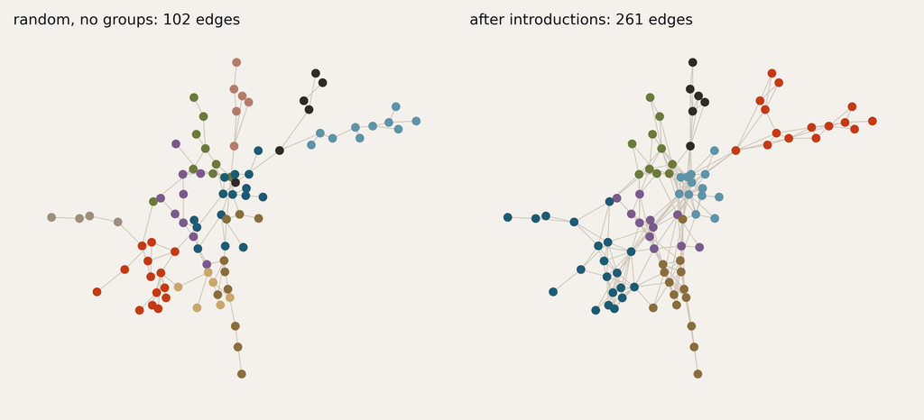

Left: random friendships between strangers, no groups by construction. Louvain colours it anyway, and some clumps, top right, look like a group to us too.

Right: every person introduces their friends to each other. Still no groups, and the clumps look even better.

So: a method that always finds clusters always finds them. Neither the picture nor the algorithm can tell you whether they are there.

6 / are the groups real?

MADS-DAV · 38

An experiment where we know the answer, because we built the network. On the left, a hundred strangers with random friendships: everyone has a random number of friends and the friends are drawn at random, so there are no groups. Louvain colours it into communities anyway, and they look like something: strands and clumps, each its own colour. Some of them, like the clump at the top right, look like a group to us as well, and that is the point: louvain and our eye are fooled by the same thing, edges that happen to fall close together. A method that always finds clusters will always find clusters. On the right, the same network after one round of introductions: every person introduces each pair of their friends to each other, with probability 0.8. That is triadic closure from question three, done on purpose. There are still no groups, nobody chose a side, nobody belongs to anything. But there are 261 edges instead of 102, most of them closing triangles, and louvain's clumps look tighter and more convincing than before. The lesson of the picture: a coloured network drawing is no evidence at all, because louvain makes one for every network. The next slide puts a number on it.

■ 6 — are the groups real?

a test for groups, and how triangles pass it

## Is Q more than chance? Rewire and compare

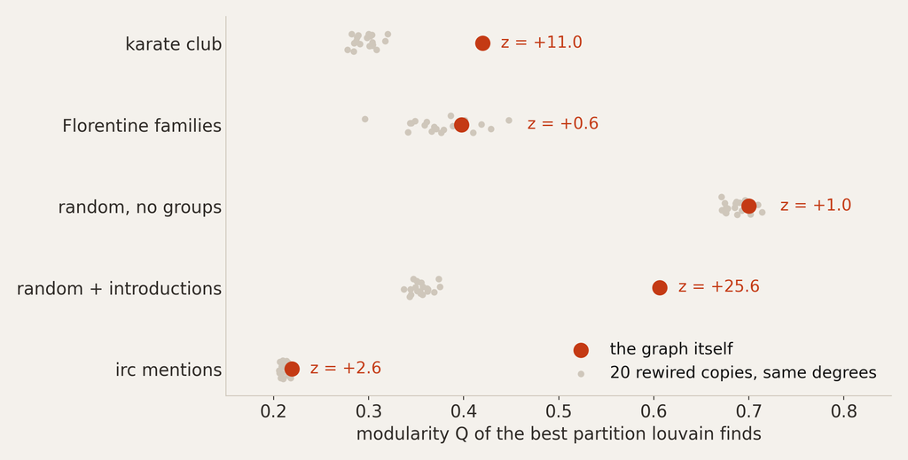

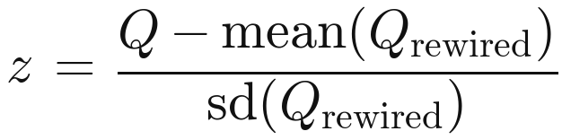

The problem: louvain gives a Q for every network, random ones too. A Q alone says nothing.

The test: rewire each network 20 times: everyone keeps their number of friends, partners are shuffled. Real groups should beat their copies (grey) by many z.

Karate: z = +11, real groups. Random: Q = 0.70, but z = +1. The test sees through it.

The catch: after introductions, z = +25.6 without any groups. Shuffling destroys triangles, so triangles alone pass.

6 / are the groups real?

MADS-DAV · 39

Now the question properly. The problem: the last slide showed that louvain finds groups in every network, and every grouping comes with a Q. So a Q on its own tells you nothing; you need to know what Q the same network would get if it had no groups. The test: make copies of the network without groups. Rewire it at random, twenty times, in a way that keeps one thing fixed: every person keeps their number of friends, only who is friends with whom is shuffled. Run louvain on each copy too. The grey dots are the copies, the vermilion dot is the real network, and z says how many standard deviations the real Q lies above its copies. If the groups are real, the real network should stand far above its copies; if they are an accident of the degrees, it sits among them. The results. The karate club: z of 11, far above, real groups, as we knew. The Florentine families: 0.6, nothing beyond what the degrees give; the Medici network was a broker network, not a set of factions. The random graph: its Q of 0.70 is the highest on the slide, and the test rightly says it is nothing, z of 1. So far the test works. The catch is the fourth row: the same random graph after introductions has z of 25.6, more than twice the karate club, and we know it has no groups. The reason is what the shuffle destroys: it keeps everyone's number of friends but not the triangles, and the introductions made triangles. So any network with many triangles passes this test, and social networks always have many triangles. The irc mention graph at 2.6 is somewhere in between; the next slide looks at it.

■ 6 — are the groups real?

matrices sorted by louvain’s communities

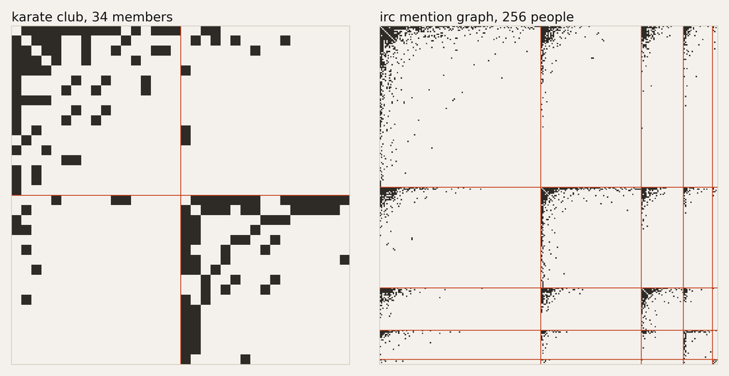

Karate: the hub rows stop at the edge of their own block, and inside it the members know each other too. Two filled squares.

Chat: each community is a hub and the people who address it. A line along the top, a line down the left, and empty inside.

6 / are the groups real?

MADS-DAV · 40

The matrix as a check on communities. How it is sorted: run louvain, put the members of the first community first, then the second, and so on, and within each community put the most connected person first, so each block starts with its hub. The vermilion lines are the borders between communities, the same kind of line as the top-ten corner in question four. Then look at what is inside each block. In the karate club, two squares that are filled: the two hubs are the dark first row and column of each block, and their rows stop at the border, while the other members of a block are connected among themselves as well. That is what a group is: people who know each other, more than they know the rest. The irc mention graph looks different. Each community is a corner with one dark row along its top and one dark column down its left, and very little inside: a hub and the people who address the hub, who do not talk to each other. And the hub rows run on into the other communities. That is a network of people who all talk to the same few regulars, and louvain has to cut it somewhere: it cuts where the hubs' circles happen to overlap least. So is that a group? The last check decides it.

● 06 — are the groups real?

Only if they beat nothing, are not just triangles, and come back.

A coloured drawing and a high Q prove nothing: louvain makes both from random friendships.

The degree-preserving null catches random graphs, not triangles. In a matrix, look for filled squares.

Then run another period. The chat’s groups did not come back.

41

Said again. Community detection always answers, so its answer is evidence only after checks. Compare with a rewired null, and remember that it does not control for triangles, which social networks are full of. Look at the matrix sorted by the communities: a real group is a filled square, people who know each other, not a hub with its audience. And see whether the communities come back in another period or with another rule. The karate club passed all three. The chat passed none convincingly, and saying so is a valid result.

● summary

a network analysis in four steps

## Choose the network, look at it twice, then check what you found

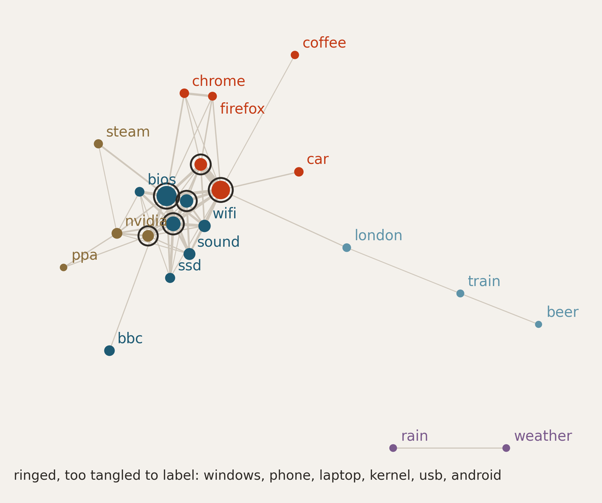

1 · brainstorm

→

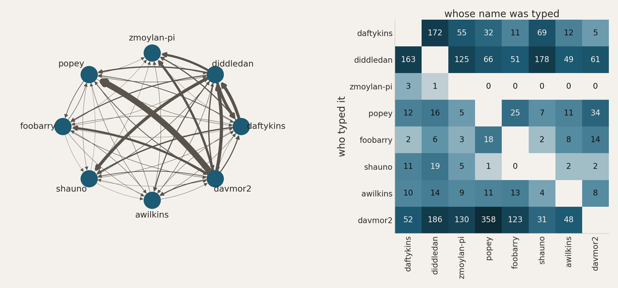

2 · draw both

→

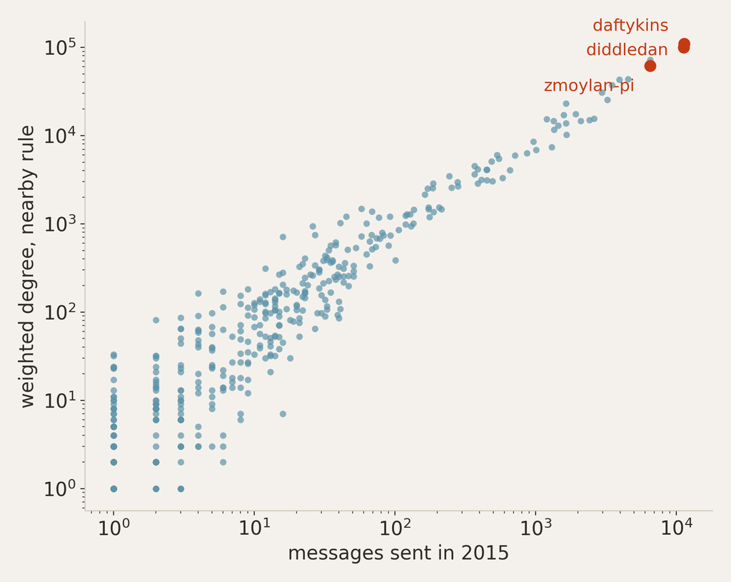

3 · what it adds

→

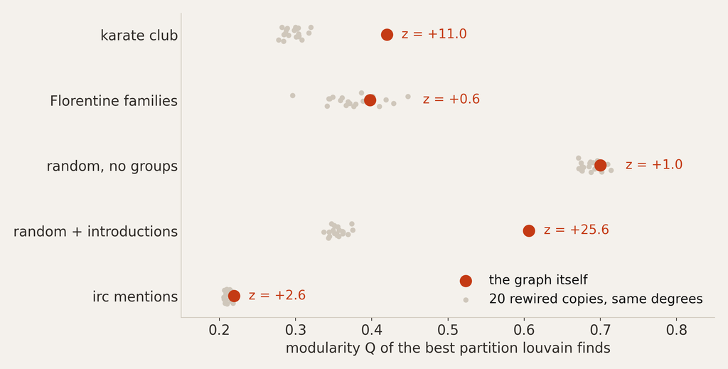

4 · against nothing

Several kinds of node and relation, each a rule with a window. Pick the one your question needs.

A drawing and a matrix, side by side. Let the clearer one carry the point.

Each measure against the column you had, as a scatter, not one number.

Groups against a null, against triangles, and in another period.

summary

MADS-DAV · 42

The lesson as the four steps of a network analysis, which are also the steps the goad coach now walks you through when your question is about connections. One: brainstorm before you build. List kinds of node, people but also things, and the relations between them, each as a rule with a window and a threshold, and choose the network your question needs. Two: look at it twice, as a drawing and as a matrix, and let whichever is clearer carry the point; a dashboard from your agent is the quickest way to see both and move the decisions. Three: compute measures only to ask what they add. Put each one next to the column you had, draw the scatter, and report it only if it says something the column did not: a broker, an open circle. Four: if you find groups, check them against nothing, a rewired copy; remember that triangles alone beat that check; and see whether the groups come back in another period. The karate club passed every step. The chat taught us that saying "there are no stable groups here" is a result you can defend.

What is a graph?

Things and their relations, G = (V, E). You choose both.

What are the nodes and edges in your chat?

People, places, things; every edge a rule with a window.

What does a graph measure add?

Brokers and open circles, or a column you had. Draw the scatter.

Graph or heatmap?

Both, side by side. Sparse wants the drawing, dense the matrix.

Can an algorithm find the groups?

Yes, best as confirmation of what you saw.

Are the groups real?

If they beat a null, are not just triangles, and come back.

Lesson 7 · Networks

43

The six questions from the start, with their answers. The notebooks work through them: 07.1 the IRC channel, the two rules, the window, a dashboard from your agent, and your own nodes and edges; 07.2 degree, betweenness, the clustering coefficient and triadic closure, a small world, spearman against a column and across windows, layouts and the matrix; 07.3 the karate club, the Fiedler vector, louvain and modularity, the null model, the introductions experiment and the chat's communities across two halves of the year. For your project: write down at least two networks your chat contains before you build one, draw every network as a drawing and as a matrix, report a measure only with what it adds over a column you had, and run the three checks before you call anything a group.

← → or click to move · F full screen · N speaker notes